# Eggs Sales Analysis Project

Phuong Le & Elena Nguyen

2025-02-09

## Introduction

#### 1. Business Problem:

The problem we are trying to solve is defining key factors that affect the sales of different egg products so that we can provide recommendations to boost sales accordingly.

#### 2. How you addressed:

We will look at the sales data for 2017, breaking it down from January to December to see if any seasonality need to be recognized. After that, we will dissect the data based on different demographic factors to identify the most common characteristics of those who specifically enjoy a certain type of egg product. The demographics here will include age, household size and whether they have kids or not. After that, we will conduct a scatter plot to examine whether display location affects the revenue.

#### 3. How helpful the analysis is:

The analysis is highly helpful as it provides actionable insights on demography, pricing strategies, and marketing opportunities to optimize sales and profitability of Eggs.

## Packages Required

The **completejourney** dataset is a dataset characterizing household level transactions over one year from a group of 2,469 households who are frequent shoppers at a grocery store.

Below is the list of all the packages we used in this project.

```r
# Data Manipulation
library(dplyr)
library(stringr)
library(tidyverse)

# Date & Time Handling
library(lubridate)

# Data Visualization
library(ggplot2)
library(ggridges)

# Datasets
library(completejourney)
```

## Data Preparation

**Overview**: The Complete Journey Dataset is a rich dataset provided by 84.51°, capturing grocery store shopping transactions over a one-year period from January 2017 - December 2017. It includes data from 2,469 households who are frequent shoppers at a retailer, providing a comprehensive view of their purchasing behavior.

In our project, we focus on analyzing the **“EGGS”** product category to understand sales trends, customer preferences, and marketing effectiveness. To achieve this, we use key tables from the Complete Journey data package:

- transactions – Contains purchase records, including product UPC, quantity, price, and transaction date.
- products – Provides product metadata such as brand, description, and category.
- demographics – Includes household characteristics like age, income, and family size.
- promotions - Contains product placement in mailers and in stores corresponding to advertising campaigns

```r
# get the completejourney - transactions dataset
transactions <- get_transactions()
transactions
```

```
## # A tibble: 1,469,307 × 11
##    household_id store_id basket_id   product_id quantity sales_value retail_disc
##    <chr>        <chr>    <chr>       <chr>         <dbl>       <dbl>       <dbl>
##  1 900          330      31198570044 1095275           1        0.5         0
##  2 900          330      31198570047 9878513           1        0.99        0.1
##  3 1228         406      31198655051 1041453           1        1.43        0.15
##  4 906          319      31198705046 1020156           1        1.5         0.29
##  5 906          319      31198705046 1053875           2        2.78        0.8
##  6 906          319      31198705046 1060312           1        5.49        0.5
##  7 906          319      31198705046 1075313           1        1.5         0.29
##  8 1058         381      31198676055 985893            1        1.88        0.21
##  9 1058         381      31198676055 988791            1        1.5         1.29
## 10 1058         381      31198676055 9297106           1        2.69        0
## # ℹ 1,469,297 more rows
## # ℹ 4 more variables: coupon_disc <dbl>, coupon_match_disc <dbl>, week <int>,
## #   transaction_timestamp <dttm>
```

```r
# get the completejourney - promotions dataset
promotions <- get_promotions()
promotions
```

```
## # A tibble: 20,940,529 × 5
##    product_id store_id display_location mailer_location  week
##    <chr>      <chr>    <fct>            <fct>           <int>
##  1 1000050    316      9                0                   1
##  2 1000050    337      3                0                   1
##  3 1000050    441      5                0                   1
##  4 1000092    292      0                A                   1
##  5 1000092    293      0                A                   1
##  6 1000092    295      0                A                   1
##  7 1000092    298      0                A                   1
##  8 1000092    299      0                A                   1
##  9 1000092    304      0                A                   1
## 10 1000092    306      0                A                   1
## # ℹ 20,940,519 more rows
```

```r
products
```

```
## # A tibble: 92,331 × 7
##    product_id manufacturer_id department    brand  product_category product_type
##    <chr>      <chr>           <chr>         <fct>  <chr>            <chr>
##  1 25671      2               GROCERY       Natio… FRZN ICE         ICE - CRUSH…
##  2 26081      2               MISCELLANEOUS Natio… <NA>             <NA>
##  3 26093      69              PASTRY        Priva… BREAD            BREAD:ITALI…
##  4 26190      69              GROCERY       Priva… FRUIT - SHELF S… APPLE SAUCE
##  5 26355      69              GROCERY       Priva… COOKIES/CONES    SPECIALTY C…
##  6 26426      69              GROCERY       Priva… SPICES & EXTRAC… SPICES & SE…
##  7 26540      69              GROCERY       Priva… COOKIES/CONES    TRAY PACK/C…
##  8 26601      69              DRUG GM       Priva… VITAMINS         VITAMIN - M…
##  9 26636      69              PASTRY        Priva… BREAKFAST SWEETS SW GDS: SW …
## 10 26691      16              GROCERY       Priva… PNT BTR/JELLY/J… HONEY
## # ℹ 92,321 more rows
## # ℹ 1 more variable: package_size <chr>
```

```r
demographics
```

```
## # A tibble: 801 × 8
##    household_id age   income    home_ownership marital_status household_size
##    <chr>        <ord> <ord>     <ord>          <ord>          <ord>
##  1 1            65+   35-49K    Homeowner      Married        2
##  2 1001         45-54 50-74K    Homeowner      Unmarried      1
##  3 1003         35-44 25-34K    <NA>           Unmarried      1
##  4 1004         25-34 15-24K    <NA>           Unmarried      1
##  5 101          45-54 Under 15K Homeowner      Married        4
##  6 1012         35-44 35-49K    <NA>           Married        5+
##  7 1014         45-54 15-24K    <NA>           Married        4
##  8 1015         45-54 50-74K    Homeowner      Unmarried      1
##  9 1018         45-54 35-49K    Homeowner      Married        5+
## 10 1020         45-54 25-34K    Homeowner      Married        2
## # ℹ 791 more rows
## # ℹ 2 more variables: household_comp <ord>, kids_count <ord>
```

## Data Analysis

#### 1. Monthly Quantity/ Sales Value Trend of Different Types of Eggs

**Data Extraction**: To analyze the general trends of egg sales in terms of revenue and quantity throughout the year of 2017, we joined the ‘products’ table with the ‘transactions’ table to draw both product category, product type, quantity and sales value to one-table setting. We also created a new column of ‘Month’ to help group data more efficiently.

```r
# Filter jam products
egg_filtered <- products %>%
  filter(product_category == "EGGS")

# Join with transactions and extract month
egg_transactions <- transactions %>%
  inner_join(egg_filtered, by = "product_id") %>%
  mutate(month = as.Date(floor_date(transaction_timestamp, "month")))

# Aggregate jam quantity by month and product type
egg_quantity <- egg_transactions %>%
  group_by(month, product_type) %>%
  summarise(total_egg_quantity = sum(quantity, na.rm = TRUE), .groups = "drop")

# Display result
egg_quantity
```

```
## # A tibble: 60 × 3
##    month      product_type    total_egg_quantity
##    <date>     <chr>                        <dbl>
##  1 2017-01-01 EGGS - JUMBO                    51
##  2 2017-01-01 EGGS - LARGE                   702
##  3 2017-01-01 EGGS - MEDIUM                  171
##  4 2017-01-01 EGGS - X-LARGE                 645
##  5 2017-01-01 EGGS SUBSTITUTE                 63
##  6 2017-02-01 EGGS - JUMBO                    42
##  7 2017-02-01 EGGS - LARGE                   542
##  8 2017-02-01 EGGS - MEDIUM                  563
##  9 2017-02-01 EGGS - X-LARGE                 454
## 10 2017-02-01 EGGS SUBSTITUTE                 35
## # ℹ 50 more rows
```

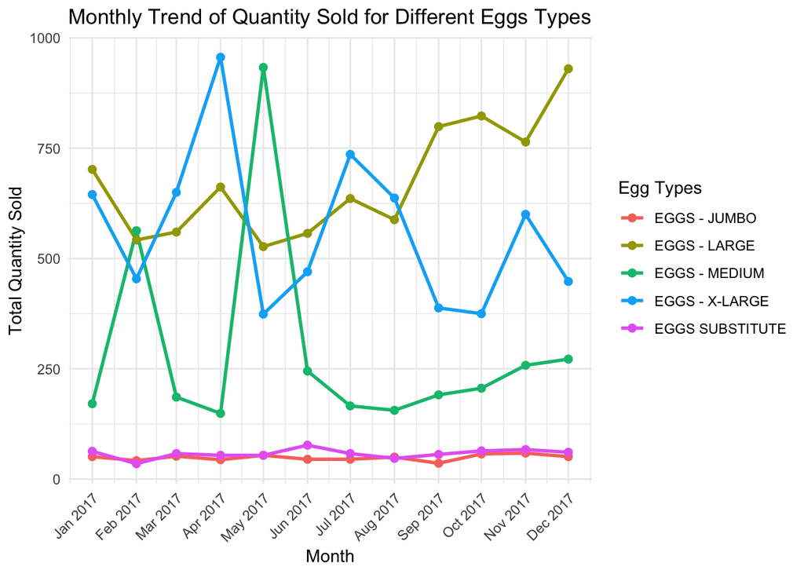

```r
# Create the line chart for quantity sold trends
ggplot(egg_quantity, aes(x = month, y = total_egg_quantity, color = product_type, group = product_type)) +
  geom_line(linewidth = 1) +
  geom_point(size = 2) +
  labs(title = "Monthly Trend of Quantity Sold for Different Eggs Types",
       x = "Month",
       y = "Total Quantity Sold",
       color = "Egg Types") +
  theme_minimal() +
  scale_x_date(date_labels = "%b %Y", date_breaks = "1 month") +
  theme(axis.text.x = element_text(angle = 45, hjust = 1))
```

```r
egg_sales <- egg_transactions %>%
  group_by(month, product_type) %>%
  summarise(total_egg_sales = sum(sales_value, na.rm = TRUE), .groups = "drop")
egg_sales
```

```
## # A tibble: 60 × 3
##    month      product_type    total_egg_sales
##    <date>     <chr>                     <dbl>
##  1 2017-01-01 EGGS - JUMBO               80.5
##  2 2017-01-01 EGGS - LARGE              916.
##  3 2017-01-01 EGGS - MEDIUM             157.
##  4 2017-01-01 EGGS - X-LARGE            730.
##  5 2017-01-01 EGGS SUBSTITUTE           169.
##  6 2017-02-01 EGGS - JUMBO               66.2
##  7 2017-02-01 EGGS - LARGE              737.
##  8 2017-02-01 EGGS - MEDIUM             275.
##  9 2017-02-01 EGGS - X-LARGE            548.
## 10 2017-02-01 EGGS SUBSTITUTE            92.3
## # ℹ 50 more rows
```

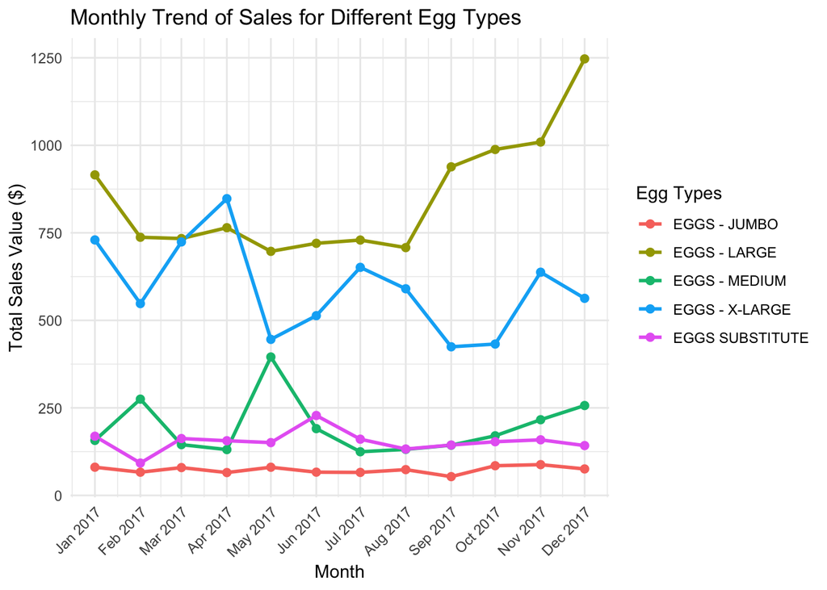

```r
# Create the line chart for quantity sold trends
ggplot(egg_sales, aes(x = month, y = total_egg_sales, color = product_type, group = product_type)) +
  geom_line(linewidth = 1) +
  geom_point(size = 2) +
  labs(title = "Monthly Trend of Sales for Different Egg Types",
       x = "Month",
       y = "Total Sales Value ($)",
       color = "Egg Types") +
  theme_minimal() +
  scale_x_date(date_labels = "%b %Y", date_breaks = "1 month") +
  theme(axis.text.x = element_text(angle = 45, hjust = 1))
```

#### 2. Compare private label vs. national brand sales performance

**Data Extraction**: The dataset egg_transactions is derived from the egg_filtered dataset by merging it with the transactions dataset based on the product_id field. It includes an additional brand_type column, categorizing brands as either “Private Brand” or “National Brand” based on the original brand column.

```r
# Classify brands as either Private Label or National Brand
egg_transactions <- egg_filtered %>%
  inner_join(transactions, by = "product_id") %>%
  mutate(brand_type = ifelse(brand == "Private", "Private Brand", "National Brand"))

# Summarize total sales by product_type and brand type
brand_comparison <- egg_transactions %>%
  group_by(product_type, brand_type) %>%
  summarise(total_sales = sum(sales_value), .groups = "drop") %>%
  arrange(product_type, desc(total_sales))

# Display the results
brand_comparison
```

```
## # A tibble: 9 × 3
##   product_type    brand_type     total_sales
##   <chr>           <chr>                <dbl>
## 1 EGGS - JUMBO    Private Brand       879.
## 2 EGGS - LARGE    Private Brand      8722.
## 3 EGGS - LARGE    National Brand     1467.
## 4 EGGS - MEDIUM   Private Brand      2333.
## 5 EGGS - MEDIUM   National Brand        3.43
## 6 EGGS - X-LARGE  Private Brand      6610.
## 7 EGGS - X-LARGE  National Brand      498.
## 8 EGGS SUBSTITUTE National Brand     1186.
## 9 EGGS SUBSTITUTE Private Brand       664.
```

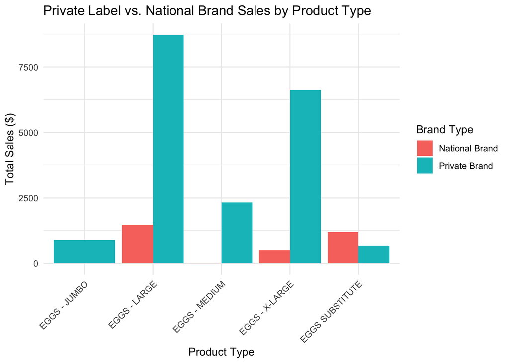

```r
ggplot(brand_comparison, aes(x = product_type, y = total_sales, fill = brand_type)) +
  geom_bar(stat = "identity", position = "dodge") +
  labs(title = "Private Label vs. National Brand Sales by Product Type",
       x = "Product Type",
       y = "Total Sales ($)",
       fill = "Brand Type") +
  theme_minimal() +
  theme(axis.text.x = element_text(angle = 45, hjust = 1))
```

#### 3. Sales Performance of Different Types of Eggs

**Data Extraction**: The dataset egg_data combines filtered egg product data with transaction records and household demographics using product_id and household_id. It includes transaction timestamps, demographic details, and a new column indicating whether a household has kids. Additionally, a month column is created to extract the transaction month.

```r
egg_data <- egg_filtered %>%
  inner_join(transactions, by = 'product_id') %>%
  inner_join(demographics, by = 'household_id') %>%
  mutate(
    month = month(transaction_timestamp),
    kids = ifelse(kids_count > 0, "Have Kid(s)", "No Kids")
)
egg_data
```

```
## # A tibble: 8,845 × 26
##    product_id manufacturer_id department brand   product_category product_type
##    <chr>      <chr>           <chr>      <fct>   <chr>            <chr>
##  1 28897      69              GROCERY    Private EGGS             EGGS - X-LARGE
##  2 28897      69              GROCERY    Private EGGS             EGGS - X-LARGE
##  3 28897      69              GROCERY    Private EGGS             EGGS - X-LARGE
##  4 28897      69              GROCERY    Private EGGS             EGGS - X-LARGE
##  5 28897      69              GROCERY    Private EGGS             EGGS - X-LARGE
##  6 28897      69              GROCERY    Private EGGS             EGGS - X-LARGE
##  7 28897      69              GROCERY    Private EGGS             EGGS - X-LARGE
##  8 28897      69              GROCERY    Private EGGS             EGGS - X-LARGE
##  9 28897      69              GROCERY    Private EGGS             EGGS - X-LARGE
## 10 28897      69              GROCERY    Private EGGS             EGGS - X-LARGE
## # ℹ 8,835 more rows
## # ℹ 20 more variables: package_size <chr>, household_id <chr>, store_id <chr>,
## #   basket_id <chr>, quantity <dbl>, sales_value <dbl>, retail_disc <dbl>,
## #   coupon_disc <dbl>, coupon_match_disc <dbl>, week <int>,
## #   transaction_timestamp <dttm>, age <ord>, income <ord>,
## #   home_ownership <ord>, marital_status <ord>, household_size <ord>,
## #   household_comp <ord>, kids_count <ord>, month <dbl>, kids <chr>
```

##### Sales Performance of Eggs Across Age Groups

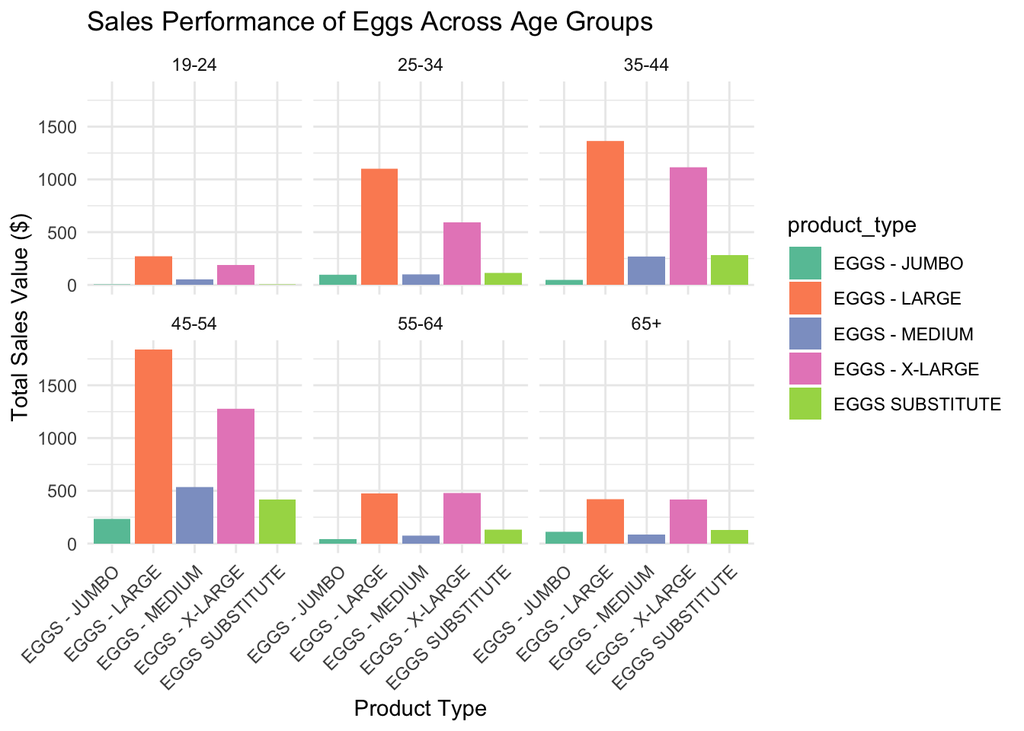

```r
ggplot(egg_data, aes(x = product_type, y = sales_value, fill = product_type)) +
  geom_bar(stat = "identity") +
  facet_wrap(~age) +
  theme(axis.text.x = element_text(angle = 90, hjust = 1, size = 9)) +
  labs(x = "Product Type", y = "Total Sales Value ($)", title = "Sales Performance of Eggs Across Age Groups") +
  scale_fill_brewer(palette = "Set2") +
  theme_minimal() +
  theme(axis.text.x = element_text(angle = 45, hjust = 1))
```

**Insights**: Overall, 25-34, 35-44 and 45-54 are the three major groups that consumed the most eggs. Regardless of age group, the largest egg types that drove the most sales are Large eggs and then X-large eggs. The group of 55-64 and over 65 seemed to have no preferences between large and extra large eggs.

##### Sales Performance of Eggs Across Household Size

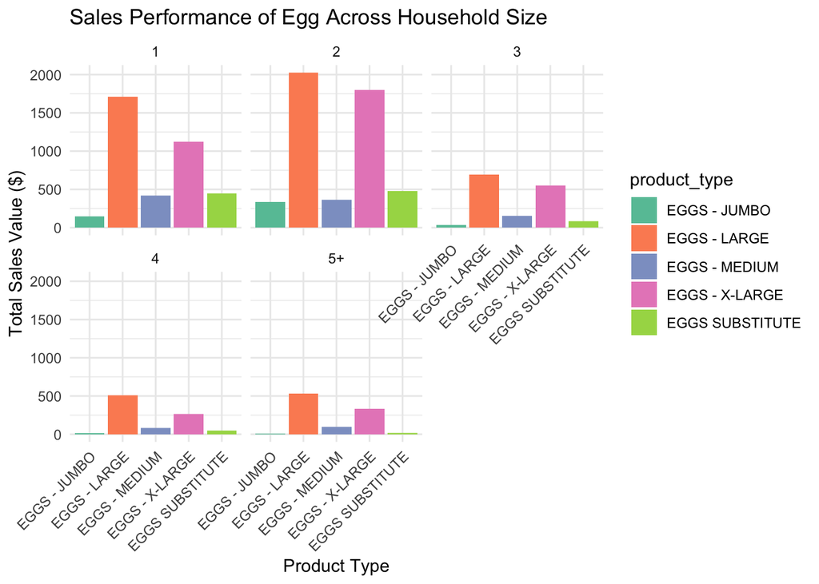

```r
ggplot(egg_data, aes(x = product_type, y = sales_value, fill = product_type)) +
  geom_bar(stat = "identity") +
  facet_wrap(~ household_size) +
  theme(axis.text.x = element_text(angle = 90, hjust = 1, size = 9)) +
  labs(x = "Product Type", y = "Total Sales Value ($)", title = "Sales Performance of Egg Across Household Size") +
  scale_fill_brewer(palette = "Set2") +
  theme_minimal() +
  theme(axis.text.x = element_text(angle = 45, hjust = 1))
```

**Insights**: Our hypothesis is that the bigger the household size, the more eggs they buy. However, the results came inversely. Single and double households bought the most eggs, more than double the three larger sizes of household.

##### Sales Performance of Eggs Across Household Type (Kids vs. No Kids)

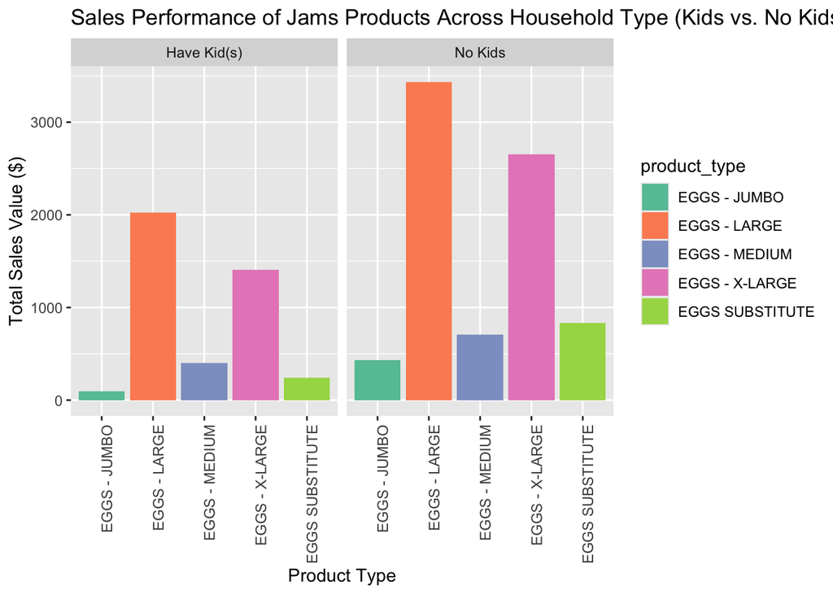

```r
ggplot(egg_data, aes(x = product_type, y = sales_value,fill = product_type)) +
  geom_bar(stat = "identity") +
  facet_wrap(~ kids) +
  theme(axis.text.x = element_text(angle = 90, hjust = 1, size = 9)) +
  labs(x = "Product Type", y = "Total Sales Value ($)", title = "Sales Performance of Jams Products Across Household Type (Kids vs. No Kids)") +
  scale_fill_brewer(palette = "Set2")
```

**Insights**: We may want to see if household types - whether a family has kids or not - will affect how many eggs they want to buy.

Surprisingly, even though eggs seem to be easy to cook and widely eaten, kids seem not to like eggs that much. Households with no kids are dominant in the sales performance of eggs, so kids are not a key determinant in the buying decision.

However, kids seem to be a key decision factor for the family to choose an egg substitute or not. Families with kids tend not to choose egg substitutes compared to households without kids.

#### 4. Sales Value by Week and Display Location

**Data Extraction**: The dataset display_egg contains information on promoted products that were successfully matched with transaction records and filtered egg products. It includes data from the promotions table (product promotions by store and week), the transactions table (sales data for those products), and the egg_filtered table (a subset of egg-related products).

```r
display_egg <- promotions %>%
inner_join(transactions, by = c('product_id', 'store_id', 'week')) %>%
inner_join(egg_filtered, by = "product_id")
```

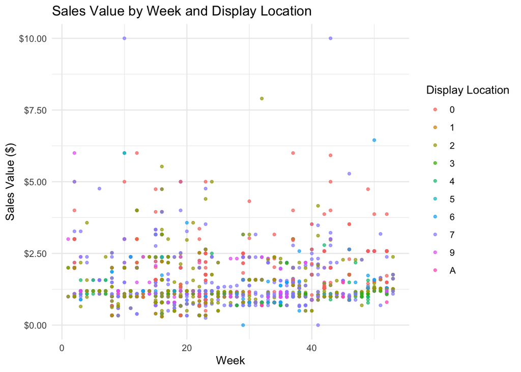

```r
ggplot(display_egg, aes(x = week, y = sales_value, color = display_location)) +
  geom_point(position = "dodge", size = 1, alpha = 0.7) +
  scale_y_continuous(labels = scales::dollar_format()) +
  labs(title = "Sales Value by Week and Display Location",
       x = "Week",
       y = "Sales Value ($)") +
  guides(color = guide_legend(title = "Display Location")) +
  theme_minimal()
```

**Insights:** Most sales values remain below $2.50, with occasional spikes reaching above $5.00 and even close to $10.00. This suggests that higher sales values are rare but do occur across different display locations. A few significant outliers (above $7.50) indicate special circumstances where “Display location 7 and 2” led to unusually high sales. Investigating these peaks can help retailers optimize product placement strategies.

## Summary

#### 1. Summarize the problem statement addressed:

In the beginning of this analysis, we would like to know what factors affect the sales of different product types of egg, so that we can conduct promotional strategies to boost more sales.

#### 2. How we answered the business problem:

To do that, we created a new table by merging ‘products’, ‘transactions’, ‘promotions’, and ‘demographics’ to get cross-table data into 1 setting with the inner_join() function. We also used mutate() to create new columns that support our analysis - to show month, demographic information and brand types. For data visualization, we use mostly line charts to illustrate trends, bar charts and various charts customized to identify the key factors that affect the total sales.

#### 3. Summarize the interesting insights that your analysis provided:

We started by dividing the data into different product types, which are different egg sizes, to see distinctive trend of each. We conducted both visualizations in terms of quantity and revenue to see if the data was consistent or if it had an underlying effect.

Regrading the scatter plot, although most sales values are below $2.50 across all display locations, we still see some outliers where “Display location 7 and 2” led to unusually high sales.

#### 5. Limitations:

There are some limitations with this analysis, so we recommend other groups should look further into promotional coupon, discount and marketing campaigns to see if they are also factors that drive sales. The data is limited in 2017, so it is challenging to justify whether this trend is still correct in the previous or the following year, considering macroeconomic factors. To define the purchase key drivers more effectively, future research may focus more on psychological factors with sentiment analysis, besides demographic data to get a more holistic view of this business question.